# Skrypt na SMLINL

Author

Damian Spodar

## Niezbędne biblkioteki

- **ggplot2** - wizualizacji danych
- **dplyr -** Manipulacja i przekształcanie danych
- **tidyr** - Czyszczenie i segregacja danych
- **caret** - Uczenie maszynowe
- **PerformanceAnalytics** - Anakuza wydajności i ryzyka
- **Knitr** - Dynamiczne generowanie dokumentów

```r
library(ggplot2)
library(dplyr)
library(caret)
library(PerformanceAnalytics)
library(knitr)
library(tidyr)
library(tseries)
library(nortest)
library(olsrr)
library(performance)
library(car)
library(lmtest)
```

## Wczytanie danych

W zależności od typu danych będziemy się poslugiwać różnymi funkcjami:

- read.csv
- read.csv2

```r
ryba <- read.csv("Fish.csv")
```

## Manipulacja i przekszalcanie danych

- head - początek ramki danych
- colsums - zlicza ilosc danych obserwacji w kolumnie
- na.omit - wypierdala wiersze z NA

```r
head(ryba)
```

```
  Species Weight Length1 Length2 Length3  Height  Width
1   Bream    242    23.2    25.4    30.0 11.5200 4.0200
2   Bream    290    24.0    26.3    31.2 12.4800 4.3056
3   Bream    340    23.9    26.5    31.1 12.3778 4.6961
4   Bream    363    26.3    29.0    33.5 12.7300 4.4555
5   Bream    430    26.5    29.0    34.0 12.4440 5.1340
6   Bream    450    26.8    29.7    34.7 13.6024 4.9274
```

```r
colSums(is.na(ryba))
```

```
Species  Weight Length1 Length2 Length3  Height   Width
      0       0       0       0       0       0       0
```

```r
ryba = na.omit(ryba)
```

## Badanie korelacji

- cor() - Zmienne muszą być numeryczne!

```r
cor(ryba[,-1]) #Usuwamy 1 kolumnę ponieważ zawiera nazwę gatunku. Jebany R się od 1 iteruje a nie jak reszta normalnych języków od 1
```

```
           Weight   Length1   Length2   Length3    Height     Width
Weight  1.0000000 0.9157117 0.9186177 0.9230436 0.7243453 0.8865066
Length1 0.9157117 1.0000000 0.9995173 0.9920310 0.6253779 0.8670497
Length2 0.9186177 0.9995173 1.0000000 0.9941026 0.6404408 0.8735467
Length3 0.9230436 0.9920310 0.9941026 1.0000000 0.7034089 0.8785202
Height  0.7243453 0.6253779 0.6404408 0.7034089 1.0000000 0.7928810
Width   0.8865066 0.8670497 0.8735467 0.8785202 0.7928810 1.0000000
```

```r
cor(ryba[, c("Weight", "Height", "Width")]) #Gdy chcemy wybrane wartośći
```

```
          Weight    Height     Width
Weight 1.0000000 0.7243453 0.8865066
Height 0.7243453 1.0000000 0.7928810
Width  0.8865066 0.7928810 1.0000000
```

## Tworzenie modeli liniowych

- lm - lineal model( Zmienna objaśniana ~ Zmienna objaśniająca1 + Zmienna objaśniająca2 + … + Zmienna objaśniająca(I-ta), data = dane z któych korzstamy)
- summary - Podaje najważniejsze informanie o modelu np : Rówanie modelu, Statystyki reszt, Szeregowe wspólczynniki regresji, Miary dopasowania modelu, Testy statystyczne

```r
model_ryba_full <- lm(Weight ~ Length1 +  Length2 +  Length3 +  Height + Width, data = ryba)
summary(model_ryba_full)
```

```
Call:
lm(formula = Weight ~ Length1 + Length2 + Length3 + Height +
    Width, data = ryba)

Residuals:
    Min      1Q  Median      3Q     Max
-243.69  -65.10  -25.52   57.98  447.25

Coefficients:
            Estimate Std. Error t value Pr(>|t|)
(Intercept) -499.587     29.572 -16.894  < 2e-16 ***
Length1       62.355     40.209   1.551  0.12302
Length2       -6.527     41.759  -0.156  0.87601
Length3      -29.026     17.353  -1.673  0.09643 .
Height        28.297      8.729   3.242  0.00146 **
Width         22.473     20.372   1.103  0.27169
---
Signif. codes:  0 '***' 0.001 '**' 0.01 '*' 0.05 '.' 0.1 ' ' 1

Residual standard error: 123.2 on 153 degrees of freedom
Multiple R-squared:  0.8853,    Adjusted R-squared:  0.8815
F-statistic: 236.2 on 5 and 153 DF,  p-value: < 2.2e-16
```

### W naszym przypadku model_ryba_full:

**Residuals(reszty)**

- Opisuje rozkład reszt (różnic między wartościami obserwowanymi a przewidywanymi)
- Idealnie powinny być symetrycznie rozłożone wokół zera
- Duże wartości skrajne mogą wskazywać na obserwacje odstające

**Coefficients (Współczynniki)**

- **Estimate**: Wartości współczynników regresji  
  Np. `Height`: 28.297 oznacza, że przy wzroście wysokości o 1 jednostkę, waga rośnie średnio o 28.297 jednostek
- **Std. Error**: Błąd standardowy oszacowania współczynnika
- **t value**: Statystyka t-testu (Estimate/Std.Error)
- **Pr(>|t|)**: p-wartość - prawdopodobieństwo, że współczynnik jest równy zero
- **Gwiazdki***: Poziomy istotności:
  - `***` **p < 0.001** (bardzo istotny)
  - `**` **p < 0.01** (istotny)
  - `*` **p < 0.05** (istotny)
  - `.` **p < 0.1** (na granicy istotności)
  - **brak gwiazdki: nieistotny** (p > 0.1)

**Residual standard error (Resztowy błąd standardowy)**

**Multiple R-squared (Współczynnik determinacji)**

- **R² = 0.8853**: Model wyjaśnia 88.53% zmienności wagi ryb
- **Adjusted R² = 0.8815**: Skorygowany współczynnik (uwzględnia liczbę predyktorów)
- Bardzo dobre dopasowanie modelu

**F-statistic (Statystyka F)**

- Testuje, czy model jako całość jest istotny
- H₀: Wszystkie współczynniki (oprócz intercept) = 0
- **p < 0.001** → model jest statystycznie istotny

## Sprawdzanie normalności blędów

Aby sprawdzić normalność blędów możemy użyć następujących testów:

**Test Shapiro–Wilka (shapiro.test(residuals(model)))**

**Zastosowanie:** małe i średnie próby (n < 5000)

**H₀:** reszty mają rozkład normalny

**H₁:** reszty nie mają rozkładu normalnego

**Test Jarque–Bera(tseries::jarque.bera.test(residuals(model)))**

Często w ekonometrii

**H₀:** reszty mają rozkład normalny

**H₁:** reszty nie mają rozkładu normalnego

**Test Andersona–Darlinga(nortest::ad.test(residuals(model)))**

Bardziej czuły na ogony rozkładu

**H₀:** reszty mają rozkład normalny

**H₁:** reszty nie mają rozkładu normalnego

**Test Craméra–von Misesa(nortest::cvm.test(residuals(model)))**

Alternatywa dla AD test

**H₀:** reszty mają rozkład normalny

**H₁:** reszty nie mają rozkładu normalnego

**Zobaczmy jak wygląda to dla naszego modelu:**

```r
shapiro.test(residuals(model_ryba_full))
```

```
    Shapiro-Wilk normality test

data:  residuals(model_ryba_full)
W = 0.952, p-value = 2.846e-05
```

```r
tseries::jarque.bera.test(residuals(model_ryba_full))
```

```
    Jarque Bera Test

data:  residuals(model_ryba_full)
X-squared = 27.307, df = 2, p-value = 1.176e-06
```

```r
nortest::ad.test(residuals(model_ryba_full))
```

```
    Anderson-Darling normality test

data:  residuals(model_ryba_full)
A = 2.4415, p-value = 3.372e-06
```

```r
nortest::cvm.test(residuals(model_ryba_full))
```

```
    Cramer-von Mises normality test

data:  residuals(model_ryba_full)
W = 0.49029, p-value = 3.285e-06
```

**Alternatywnie z biblioteki olsrr:**

```r
ols_test_normality(model_ryba_full)
```

```
-----------------------------------------------
       Test             Statistic       pvalue
-----------------------------------------------
Shapiro-Wilk              0.952          0.0000
Kolmogorov-Smirnov        0.1263         0.0125
Cramer-von Mises         15.4443         0.0000
Anderson-Darling          2.4415         0.0000
-----------------------------------------------
```

Jak widzimy w naszym modelu każdy z testów dal p_value<0.05 (Rozsądny poziom istotnośći) więc odrzucamy **H₀** w związku z tym reszty modelu nie mają rozkladu normalnego

## Wykresy pomocne przy sprawdzaniu normalnośći blędów

Wykresy stosujemy razem z testami `Obowiązkowo`

#### ols_plot_resid_qq()

W prawidlowej sytuacji gdy normalnosc wystepuje punkty ukladaja sie wzdluż czerwonej linii (dopuszczalne są lekkie odchylenia na końcach)

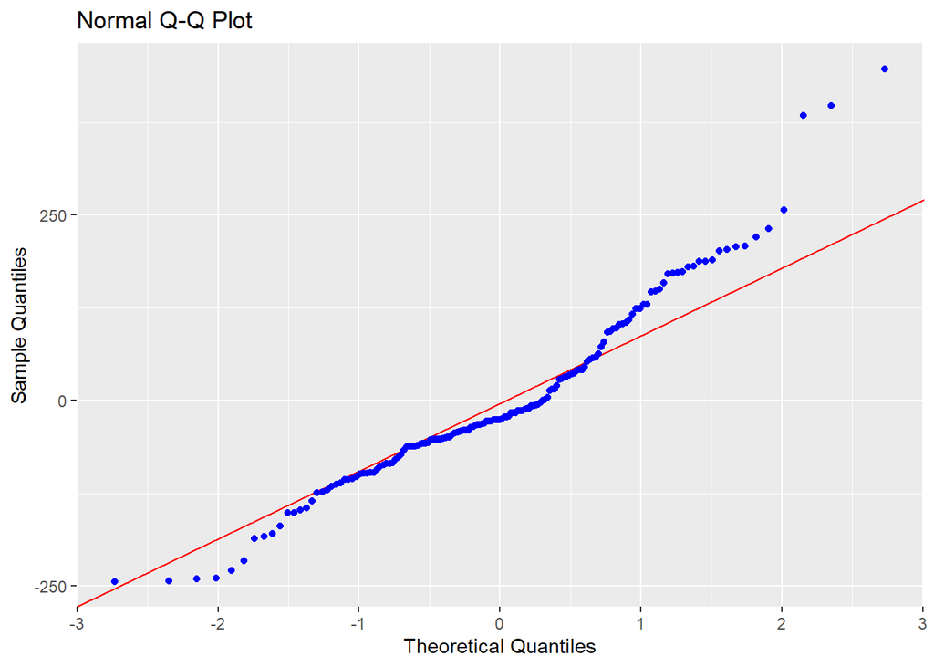

```r
olsrr::ols_plot_resid_qq(model_ryba_full)
```

Możemy zauważyć iż punkty odbiegają od linii więc nie występuje tu normalność

#### ols_plot_resid_fit()

Gdy normalność występuje można zauważyć rozproszoną chmurę punktów, nie tworzących zadnego zagęszczenia

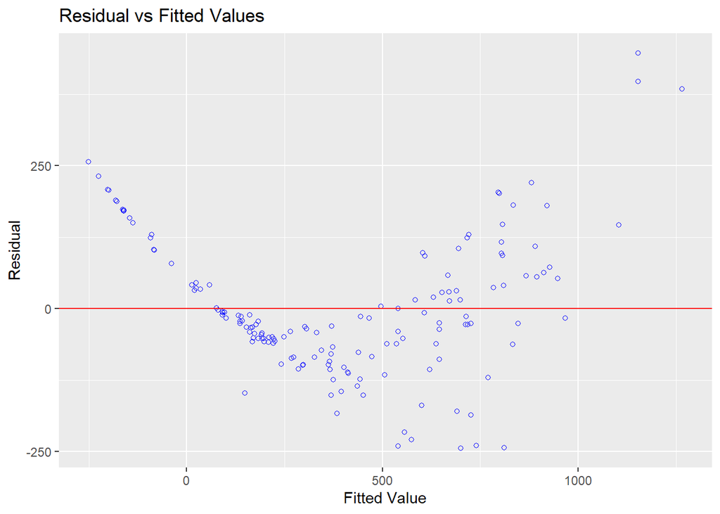

```r
olsrr::ols_plot_resid_fit(model_ryba_full)
```

Jak widać reszty nie są ulożone równo wokól zera więc zostalo naruszone zalożenie o normalnośći bledow

#### ls_plot_resid_stud()

Wykres reszt studentyznowanych pokazuje nam wartości odstające

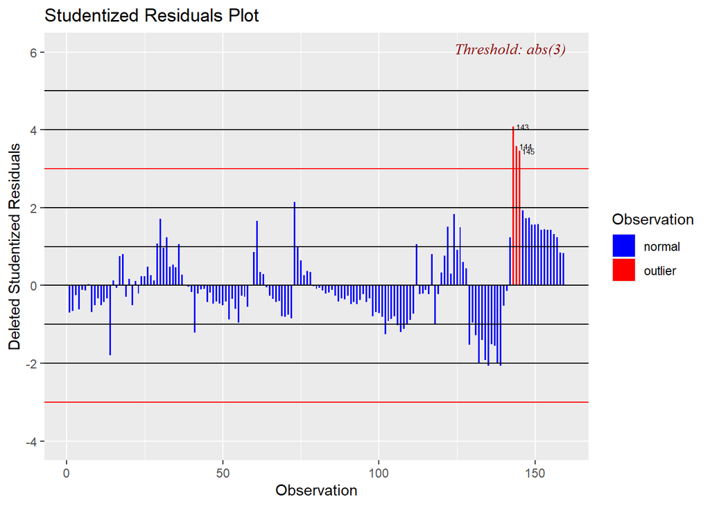

```r
olsrr::ols_plot_resid_stud(model_ryba_full)
```

Możemy zauważyć iż kilka z nich znacznie odstaje od reszty, mogą być przyczyną braku normalności oraz heteroskedastyczności

#### Alternatywnie(z pakietu preformance oraz see):

```
For confidence bands, please install `qqplotr`.
```

```
Ignoring unknown labels:
• size : ""
```

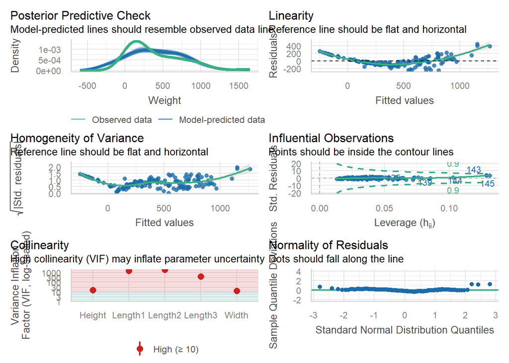

```r
diag<- plot(performance::check_model(model_ryba_full, panel = TRUE))
```

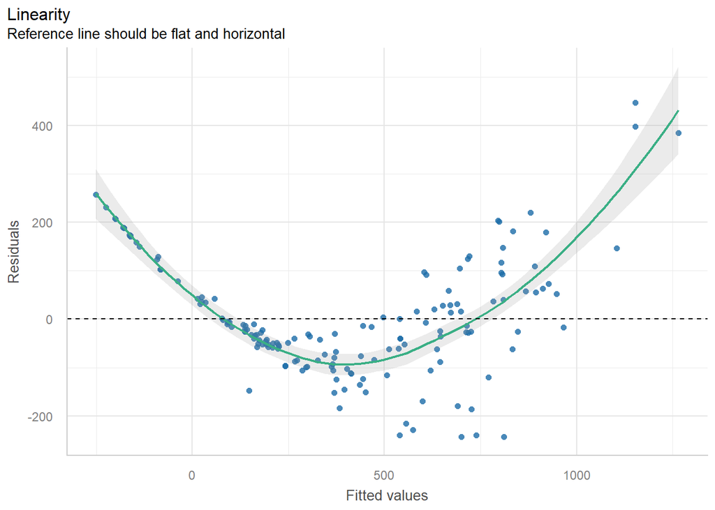

```r
diag[[2]]
```

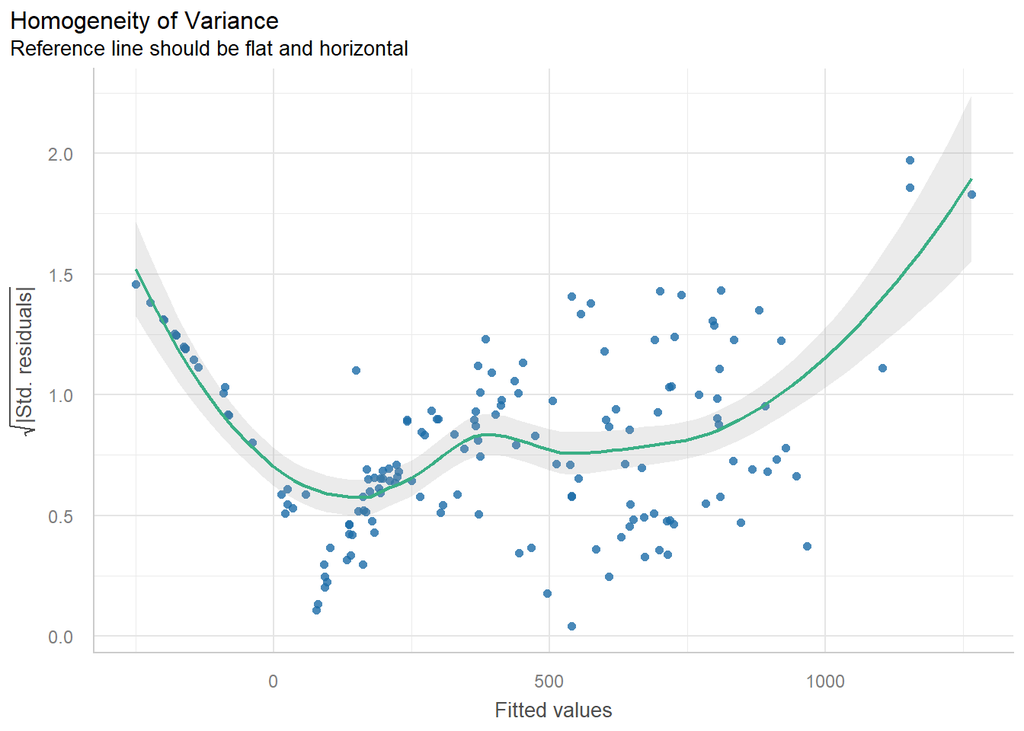

```r
diag[[3]]
```

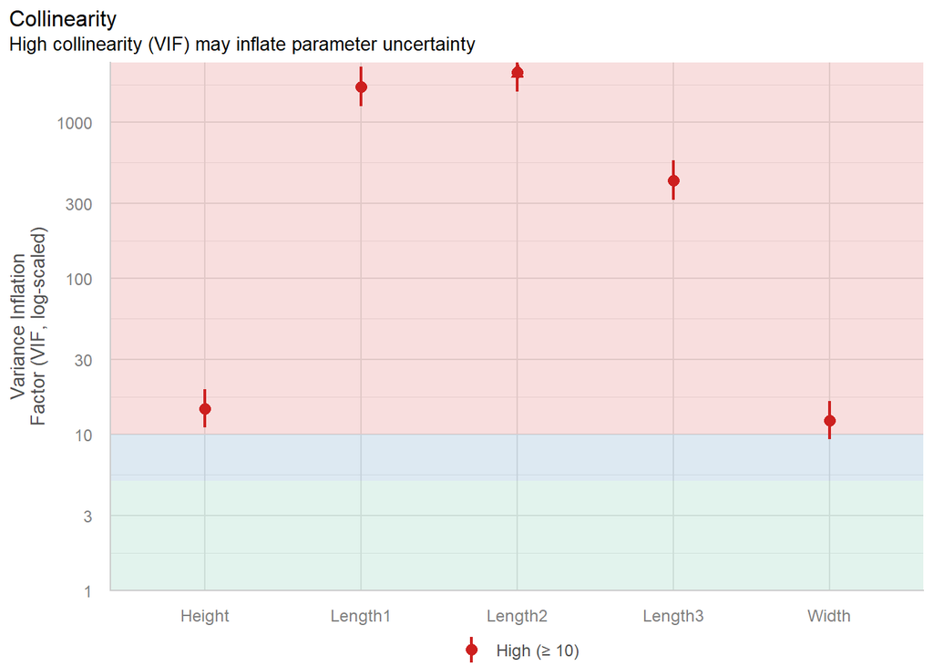

```r
diag[[5]]
```

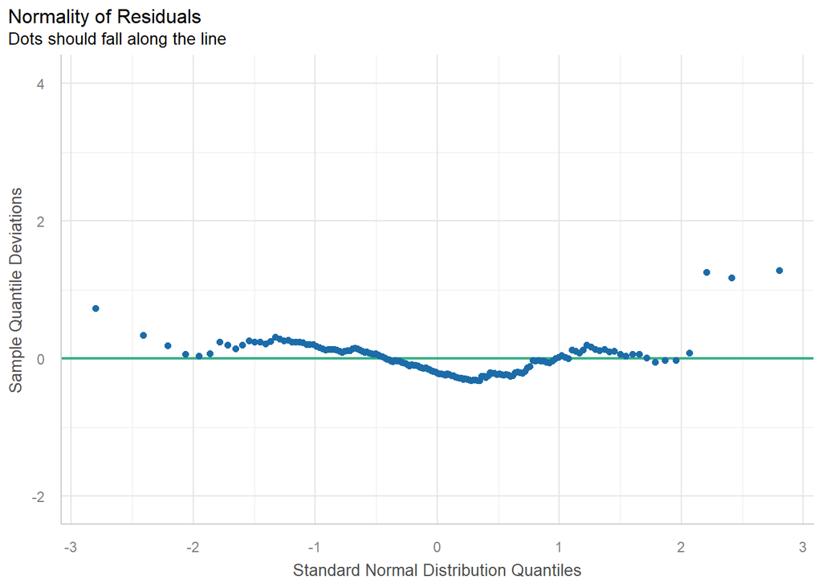

```r
diag[[6]]
```

## Sprawdzanie obserwacji nietypowych

Aby sprawdzić któe obserwacje są nietypowe możemy użyć testów

**Test Bonferroniego(car::outlierTest(model_ryba_full))**

Sprawdza ekstremalne reszty.

**H₀:** brak obserwacji odstających

**H₁:** istnieją obserwacje odstające

```r
#Nie sugerować się do konca tym testem ale bardziej miarami
outlierTest(model_ryba_full)
```

```
    rstudent unadjusted p-value Bonferroni p
143 4.082911         7.1667e-05     0.011395
```

*Miara DFFITS*

```r
dff <- dffits(model_ryba_full)
n <- nobs(model_ryba_full)
p <- length(coef(model_ryba_full))

which(abs(dff) > 2 * sqrt(p / n))
```

```
 30  73 131 132 134 135 138 139 143 144 145 146
 30  73 131 132 134 135 138 139 143 144 145 146
```

*Miara DFBTAS*

```r
dfb <- dfbetas(model_ryba_full)

which(apply(abs(dfb), 1, max) > 2 / sqrt(n))
```

```
 30  73 102 107 112 124 130 131 132 134 135 139 142 143 144 145 146 147 148 149
 30  73 102 107 112 124 130 131 132 134 135 139 142 143 144 145 146 147 148 149
150 151 152 153 154 155 156 157
150 151 152 153 154 155 156 157
```

*Iloraz kowariancji*

```r
covr <- covratio(model_ryba_full)

which(abs(covr - 1) > 3 * p / n)
```

```
114 119 143 144 145
114 119 143 144 145
```

Jak widać w naszym przykladzie obserwacje 143, 144 oraz 145 są obserwacjami najbardziej wplywowymi w calym zbiorze i w związku z tym zostają usunięte w celu poprawienia parametrów modelu

```r
outliers <- c(143, 144, 145)
ryba_clean <- ryba[-outliers, ]
model_ryba_clean <- lm(Weight ~ Height, data = ryba_clean)
summary(model_ryba_clean)
```

```
Call:
lm(formula = Weight ~ Height, data = ryba_clean)

Residuals:
    Min      1Q  Median      3Q     Max
-329.22  -97.22  -52.21   46.04  771.97

Coefficients:
            Estimate Std. Error t value Pr(>|t|)
(Intercept) -155.177     35.347   -4.39  2.1e-05 ***
Height        59.254      3.558   16.65  < 2e-16 ***
---
Signif. codes:  0 '***' 0.001 '**' 0.01 '*' 0.05 '.' 0.1 ' ' 1

Residual standard error: 191.5 on 154 degrees of freedom
Multiple R-squared:  0.643, Adjusted R-squared:  0.6407
F-statistic: 277.4 on 1 and 154 DF,  p-value: < 2.2e-16
```

## Homoskedastyczność

### Homoskedastyczność = homogeniczność(jednorodność wariancji bledów)

Wszystkie blędy mają jednakową wariancję

Oto testy do jej sprawdzenia:

**Test Breuscha–Pagana(lmtest::bptest(model_ryba_full))**

**H₀:** wariancja składnika losowego jest stała

**H₁:** wariancja nie jest stała (heteroskedastyczność)

```r
bptest(model_ryba_full)
```

```
    studentized Breusch-Pagan test

data:  model_ryba_full
BP = 78.622, df = 5, p-value = 1.629e-15
```

Test Breuscha–Pagana wskazał na istotne naruszenie założenia homoskedastyczności składnika losowego (BP = 78.622, p < 0.001). Oznacza to, że wariancja reszt nie jest stała i zależy od poziomu zmiennych objaśniających.

**Test Goldfelda–Quandta(lmtest::gqtest(model))**

**H₀:** homoskedastyczność (stała wariancja reszt)

**H₁:** heteroskedastyczność (wariancje różne)

```r
lmtest::gqtest(model_ryba_full)
```

```
    Goldfeld-Quandt test

data:  model_ryba_full
GQ = 4.0226, df1 = 74, df2 = 73, p-value = 5.283e-09
alternative hypothesis: variance increases from segment 1 to 2
```

Najbardziej ogólny test heteroskedastyczności – bez założeń co do jej formy.

**H₀:** homoskedastyczność

**H₁:** heteroskedastyczność dowolnej postaci

```r
lmtest::bptest(model_ryba_full)
```

```
    studentized Breusch-Pagan test

data:  model_ryba_full
BP = 78.622, df = 5, p-value = 1.629e-15
```

**Test Harrisona–McCabe’a(lmtest::hmctest(model))**

Sprawdza, czy ich wariancja systematycznie rośnie lub maleje w kolejnych obserwacjach.

**H₀:** homoskedastyczność (stała wariancja reszt)

**H₁:** heteroskedastyczność (wariancja zmienna w czasie)

```r
lmtest::hmctest(model_ryba_full)
```

```
    Harrison-McCabe test

data:  model_ryba_full
HMC = 0.22115, p-value < 2.2e-16
```

**Test Koenkera–Basseta(lmtest::bptest(model, studentize = FALSE))**

**H₀:** homoskedastyczność (stała wariancja reszt)

**H₁:** heteroskedastyczność (wariancja zależna od regresorów)

```r
lmtest::bptest(model_ryba_full, studentize = FALSE)
```

```
    Breusch-Pagan test

data:  model_ryba_full
BP = 128.5, df = 5, p-value < 2.2e-16
```

- **Wykres reszt od wartosci dopasowanych**

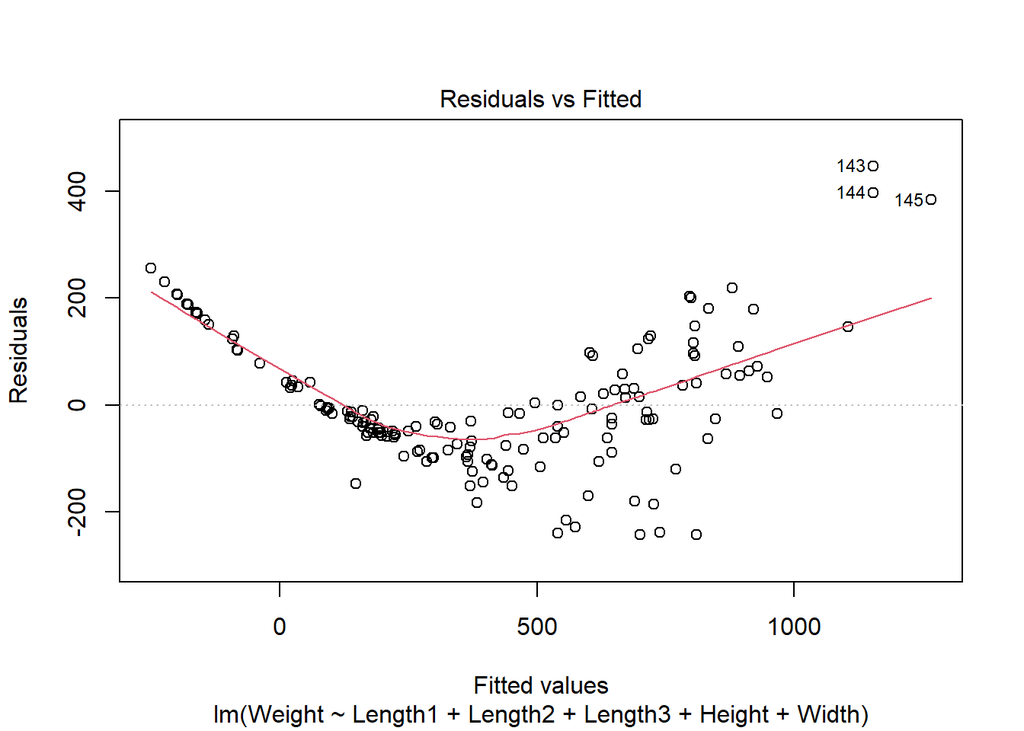

  ```r
  plot(model_ryba_full, which = 1)
  ```

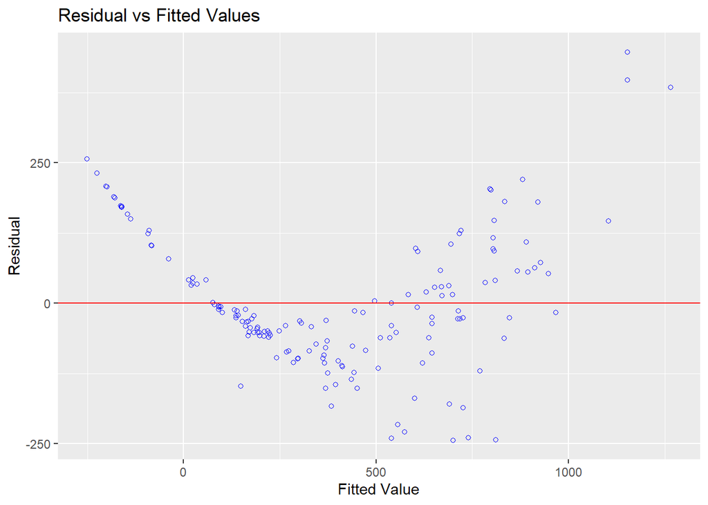

  ```r
  olsrr::ols_plot_resid_fit(model_ryba_full)
  ```

## Autokorelacja reszt

**Test Durbin–Watsona(lmtest::dwtest(model_ryba_full))**

**H₀:** brak autokorelacji reszt

**H₁:** występuje autokorelacja

```r
lmtest::dwtest(model_ryba_full)
```

```
    Durbin-Watson test

data:  model_ryba_full
DW = 0.42372, p-value < 2.2e-16
alternative hypothesis: true autocorrelation is greater than 0
```

```r
car::durbinWatsonTest(model_ryba_full)
```

```
 lag Autocorrelation D-W Statistic p-value
   1       0.7843536     0.4237245       0
 Alternative hypothesis: rho != 0
```

Ponieważ p_value w teście Durbina-Watsona jest mniejsze od każdego sensownie przyjętego poziomu ufności oznacza to iż obalamy hipotezę zerową. W związku z tym w modelu reszty są skorelowane

**Test Breucha-Godfreya**

**H₀:** brak autokorelacji reszt

**H₁:** występuje autokorelacja

```r
lmtest::bgtest(model_ryba_full)
```

```
    Breusch-Godfrey test for serial correlation of order up to 1

data:  model_ryba_full
LM test = 100.79, df = 1, p-value < 2.2e-16
```

### Liniowość modelu

Testy używane do badania liniowośći modelu:

**Rainbow(lmtest::raintest(model_ryba_full))**

**H₀:** model jest liniowy (poprawnie wyspecyfikowany)

**H₁:** model jest nieliniowy (błędna specyfikacja)

```r
lmtest::raintest(model_ryba_full)
```

```
    Rainbow test

data:  model_ryba_full
Rain = 5.468, df1 = 80, df2 = 73, p-value = 2.045e-12
```

Jak widać p_value < 0.05 wiec odrzucamy **H₀** - model jest więc nieliniowy

**Test Ramsey’a RESET(lmtest::resettest(model, power = 2:3))**

Stosujemy power = 2:3 ponieważ potęga 1 jest już w modelu

**H₀:** model jest poprawnie wyspecyfikowany

**H₁:** model jest źle wyspecyfikowany

```r
lmtest::resettest(model_ryba_full, power = 2:3)
```

```
    RESET test

data:  model_ryba_full
RESET = 358.53, df1 = 2, df2 = 151, p-value < 2.2e-16
```

**Test Harveya–Colliera(lmtest::harvtest(model))**

Najlepszy dla danych uporządkowanych(np. Czasowych)

**H₀:** model jest liniowy

**H₁:** model jest nieliniowy

```r
lmtest::harvtest(model_ryba_full)
```

```
    Harvey-Collier test

data:  model_ryba_full
HC = 2.8944, df = 152, p-value = 0.004358
```

## Współliniowość dokładna

Jedna zmienna objaśniająca jest **dokładną kombinacją liniową innych**

Zbudujmy model z danych `Advertising.csv` taki w ktorym wszystkie wspoczynniki sa istotne statystycznie

```r
reklamy <- read.csv2("Advertising.csv")
model_reklamy <- lm(sales ~ TV + radio, data = reklamy)
summary(model_reklamy)
```

```
Call:
lm(formula = sales ~ TV + radio, data = reklamy)

Residuals:
    Min      1Q  Median      3Q     Max
-8.7921 -0.8758  0.2443  1.1491  2.8768

Coefficients:
            Estimate Std. Error t value Pr(>|t|)
(Intercept) 2.869220   0.296495   9.677   <2e-16 ***
TV          0.045846   0.001389  32.998   <2e-16 ***
radio       0.189161   0.008072  23.434   <2e-16 ***
---
Signif. codes:  0 '***' 0.001 '**' 0.01 '*' 0.05 '.' 0.1 ' ' 1

Residual standard error: 1.678 on 196 degrees of freedom
Multiple R-squared:  0.8976,    Adjusted R-squared:  0.8966
F-statistic:   859 on 2 and 196 DF,  p-value: < 2.2e-16
```

Sprawdzamy to za pomocą korelacji

```r
cor(reklamy$TV,reklamy$radio)
```

```
[1] 0.04902701
```

Wynik nie jest bliski 1 więc wspólliniowość dokladna nie występuje

## Współliniowość niedokładna (multikolinearność)

Test VIF

```r
car::vif(model_reklamy)
```

```
      TV    radio
1.002409 1.002409
```

Interpretacja:

- **VIF < 5 brak problemu**
- **VIF < 10 brak istotnej współliniowości**

Macierz korelacji

```r
cor(reklamy[,c("TV","radio")])
```

```
              TV      radio
TV    1.00000000 0.04902701
radio 0.04902701 1.00000000
```

Im bliższe 0 tym lepiej

## Badanie egzogeniczności zmiennych

Zmienna egzogeniczna to taka która nie jest skorelowana ze skladnikiem losowm (Brak jakichkolwiek korelacji z zewnatrz)- efekt porządany

- **Badanie za pomocą macierzy korelacji**

```r
cor(resid(model_reklamy), reklamy[,c("TV","radio")])
```

```
                TV         radio
[1,] -1.268408e-17 -5.807125e-17
```

Korelacje praktycznie zerowe więc zmienne są egzogenicze

- **Test Hausman (H₀:** **Zmienna jest egzogeniczna**)

  Przeprowadzimy go na modelu zbudowanego na zbiorze CigarettesSW

  sprawdzimy czy zmienna price jest endogeniczna i czy jej instrumentem jest tax

  (Czyli po prostu czy cena jest związana z podatkiem)

  **INSTRUMENT MUSI BYĆ SKORELOWANY ZE ZMIENNĄ ALE NIE MOŻE BYĆ SKORELOWANY Z BLEDEM**

```r
dane_papierosy <- data("CigarettesSW",package = "AER")
model_papierzosy <- lm(packs ~ price + income, data = CigarettesSW)
summary(model_papierzosy)
```

```
Call:
lm(formula = packs ~ price + income, data = CigarettesSW)

Residuals:
    Min      1Q  Median      3Q     Max
-55.266 -10.092  -0.428   6.078  69.298

Coefficients:
              Estimate Std. Error t value Pr(>|t|)
(Intercept)  1.635e+02  6.885e+00  23.740  < 2e-16 ***
price       -3.596e-01  4.861e-02  -7.398 6.01e-11 ***
income      -2.702e-08  1.770e-08  -1.527     0.13
---
Signif. codes:  0 '***' 0.001 '**' 0.01 '*' 0.05 '.' 0.1 ' ' 1

Residual standard error: 19.57 on 93 degrees of freedom
Multiple R-squared:  0.4398,    Adjusted R-squared:  0.4277
F-statistic:  36.5 on 2 and 93 DF,  p-value: 1.992e-12
```

Będziemy potrzebować drugiego modelu, aby sprawdzić czy faktycznie tak jest i zastosować test **Hausmana** użyjemy do tego funkcji `AER::ivreg`

```r
model_test_Hausmana<- AER::ivreg(packs ~ price + income | tax + income, data = CigarettesSW)

summary(model_test_Hausmana, diagnostics = TRUE)
```

```
Call:
AER::ivreg(formula = packs ~ price + income | tax + income, data = CigarettesSW)

Residuals:
      Min        1Q    Median        3Q       Max
-56.16120 -10.40243   0.07866   6.87649  67.85671

Coefficients:
              Estimate Std. Error t value Pr(>|t|)
(Intercept)  1.685e+02  7.673e+00  21.957  < 2e-16 ***
price       -3.979e-01  5.502e-02  -7.232 1.31e-10 ***
income      -2.231e-08  1.803e-08  -1.238    0.219

Diagnostic tests:
                 df1 df2 statistic p-value
Weak instruments   1  93   341.145  <2e-16 ***
Wu-Hausman         1  92     2.312   0.132
Sargan             0  NA        NA      NA
---
Signif. codes:  0 '***' 0.001 '**' 0.01 '*' 0.05 '.' 0.1 ' ' 1

Residual standard error: 19.64 on 93 degrees of freedom
Multiple R-Squared: 0.436,  Adjusted R-squared: 0.4239
Wald test: 35.23 on 2 and 93 DF,  p-value: 4.081e-12
```

Patrzymy na `Weak instruments: statistic = 341.145, p-value < 2e-16`

widzimy iż p_value jest niemal równe zero co świadczy o tym iż instrument `tax` wplywa na `price`

Teraz **Test Hausmana** `Wu-Hausman: statistic = 2.312, p-value = 0.132`

możemy zauważyć iż p_value > 0.05 w związku z tym nie ma podstaw do odrzucenia **H₀ (Zmienna jest egzogeniczna)**

## Interpretacja modelu

```r
summary(model_test_Hausmana)
```

```
Call:
AER::ivreg(formula = packs ~ price + income | tax + income, data = CigarettesSW)

Residuals:
      Min        1Q    Median        3Q       Max
-56.16120 -10.40243   0.07866   6.87649  67.85671

Coefficients:
              Estimate Std. Error t value Pr(>|t|)
(Intercept)  1.685e+02  7.673e+00  21.957  < 2e-16 ***
price       -3.979e-01  5.502e-02  -7.232 1.31e-10 ***
income      -2.231e-08  1.803e-08  -1.238    0.219
---
Signif. codes:  0 '***' 0.001 '**' 0.01 '*' 0.05 '.' 0.1 ' ' 1

Residual standard error: 19.64 on 93 degrees of freedom
Multiple R-Squared: 0.436,  Adjusted R-squared: 0.4239
Wald test: 35.23 on 2 and 93 DF,  p-value: 4.081e-12
```

- Jeśli cena paczki wzrośnie o 1 jednostkę to liczba kupowanych paczek spadnie o 0.4 jednostek przy niezmienionym dochodzie
- Wplyw dochodu jest prawie zerowy, nie wplywa na kupno papierosów

## Tranfsormacje

- **Logarytmiczna**

```r
model_log <- lm(data =CigarettesSW, income ~ log(price))
summary(model_log)
```

```
Call:
lm(formula = income ~ log(price), data = CigarettesSW)

Residuals:
       Min         1Q     Median         3Q        Max
-139100563  -55856080  -31807958   24423517  616776187

Coefficients:
              Estimate Std. Error t value Pr(>|t|)
(Intercept) -528159579  190936410  -2.766  0.00683 **
log(price)   127647918   38734509   3.295  0.00139 **
---
Signif. codes:  0 '***' 0.001 '**' 0.01 '*' 0.05 '.' 0.1 ' ' 1

Residual standard error: 114700000 on 94 degrees of freedom
Multiple R-squared:  0.1036,    Adjusted R-squared:  0.09403
F-statistic: 10.86 on 1 and 94 DF,  p-value: 0.001387
```

| Postać modelu | Zmienna objaśniana (Y) | Zmienna objaśniająca (X) | Interpretacja współczynnika przy X |
| --- | --- | --- | --- |
| **lin–lin** | (Y) | (X) | Wzrost zmiennej (X) o 1 jednostkę powoduje średnią zmianę zmiennej (Y) o (\beta_1) jednostek. |
| **log–lin** | (\log(Y)) | (X) | Wzrost zmiennej (X) o 1 jednostkę powoduje średnią zmianę zmiennej (Y) o około (\beta_1 \cdot 100%). |
| **lin–log** | (Y) | (\log(X)) | Wzrost zmiennej (X) o 1% powoduje średnią zmianę zmiennej (Y) o (0{,}01 \cdot \beta_1) jednostki. |
| **log–log** | (\log(Y)) | (\log(X)) | Wzrost zmiennej (X) o 1% powoduje średnią zmianę zmiennej (Y) o (\beta_1%). |

- **Box-Cox**

```r
car::powerTransform(CigarettesSW$income)
```

```
Estimated transformation parameter
CigarettesSW$income
        -0.01017597
```

```r
car::powerTransform(CigarettesSW$price)
```

```
Estimated transformation parameter
CigarettesSW$price
        -0.4179132
```

| Parametr λ | Zmienna objaśniana (Y) | Zmienna objaśniająca (X) | Postać modelu | Interpretacja współczynnika przy X |
| --- | --- | --- | --- | --- |
| λ = 1 | (Y) | (X) | lin–lin | Wzrost zmiennej (X) o 1 jednostkę powoduje średnią zmianę zmiennej (Y) o (\beta_1) jednostek. |
| λ ≈ 0 | (\log(Y)) | (\log(X)) | log–log | Wzrost zmiennej (X) o 1% powoduje średnią zmianę zmiennej (Y) o (\beta_1%). |
| λ ∈ (0,1) | (Y^{(\lambda)}) | (X^{(\lambda)}) | potęga–potęga | Wzrost przekształconej zmiennej (X^{(\lambda)}) o 1 jednostkę powoduje średnią zmianę (Y^{(\lambda)}) o (\beta_1) jednostek. |
| λ < 0 | (Y^{(\lambda)}) | (X^{(\lambda)}) | odwrotność / potęga ujemna | Wzrost przekształconej zmiennej (X^{(\lambda)}) o 1 jednostkę powoduje średnią zmianę (Y^{(\lambda)}) o (\beta_1) jednostek. |

**Uwaga:** W przypadku transformacji Boxa–Coxa interpretacja współczynników dotyczy zmiennych po transformacji. Bezpośrednia interpretacja w jednostkach oryginalnych jest utrudniona i najczęściej nie jest prowadzona.

Model zbudowany po transformacji **Box-Cox**

```r
lambda_income <- -0.01017597
lambda_price  <- -0.4179132

model_bc <- lm(
  packs ~ car::bcPower(price,-0.4179132) + car::bcPower(income, -0.01017597),
  data = CigarettesSW
)
summary(model_bc)
```

```
Call:
lm(formula = packs ~ car::bcPower(price, -0.4179132) + car::bcPower(income,
    -0.01017597), data = CigarettesSW)

Residuals:
    Min      1Q  Median      3Q     Max
-53.803 -10.902  -1.405   7.352  68.189

Coefficients:
                                  Estimate Std. Error t value Pr(>|t|)
(Intercept)                       1008.747    110.168   9.156 1.25e-14 ***
car::bcPower(price, -0.4179132)   -418.882     55.986  -7.482 4.03e-11 ***
car::bcPower(income, -0.01017597)   -1.623      2.405  -0.675    0.501
---
Signif. codes:  0 '***' 0.001 '**' 0.01 '*' 0.05 '.' 0.1 ' ' 1

Residual standard error: 19.93 on 93 degrees of freedom
Multiple R-squared:  0.419, Adjusted R-squared:  0.4065
F-statistic: 33.54 on 2 and 93 DF,  p-value: 1.078e-11
```

# Metody selekcji w przód oraz elminacji wstecznej

## Metoda selekcji w przód

Robimy model który zaczyna się od modelu z wyrazem wolnym następnie dodajemy poszczególne zmienne

```r
# Model początkowy (tylko wyraz wolny)
początkowy_model <- lm(Employed ~ 1, data = datasets::longley)

# Model pełny (wszystkie zmienne)
pelny_model <- lm(Employed ~ ., data = datasets::longley)

# Selekcja w przód
wprzod_model <- step(początkowy_model, scope = list(lower = początkowy_model, upper = pelny_model), direction = "forward")
```

```
Start:  AIC=41.17
Employed ~ 1

               Df Sum of Sq     RSS     AIC
+ GNP           1   178.973   6.036 -11.597
+ Year          1   174.552  10.457  -2.806
+ GNP.deflator  1   174.397  10.611  -2.571
+ Population    1   170.643  14.366   2.276
+ Unemployed    1    46.716 138.293  38.509
+ Armed.Forces  1    38.691 146.318  39.411
<none>                      185.009  41.165

Step:  AIC=-11.6
Employed ~ GNP

               Df Sum of Sq    RSS      AIC
+ Unemployed    1   2.45708 3.5791 -17.9598
+ Population    1   2.16178 3.8744 -16.6913
+ Year          1   1.12520 4.9109 -12.8980
<none>                      6.0361 -11.5972
+ GNP.deflator  1   0.21194 5.8242 -10.1691
+ Armed.Forces  1   0.07665 5.9595  -9.8017

Step:  AIC=-17.96
Employed ~ GNP + Unemployed

               Df Sum of Sq    RSS     AIC
+ Armed.Forces  1   0.82235 2.7567 -20.137
<none>                      3.5791 -17.960
+ Year          1   0.33980 3.2393 -17.556
+ Population    1   0.09682 3.4822 -16.399
+ GNP.deflator  1   0.01884 3.5602 -16.044

Step:  AIC=-20.14
Employed ~ GNP + Unemployed + Armed.Forces

               Df Sum of Sq     RSS     AIC
+ Year          1   1.89803 0.85868 -36.799
+ Population    1   0.39011 2.36660 -20.578
<none>                      2.75671 -20.137
+ GNP.deflator  1   0.07288 2.68383 -18.566

Step:  AIC=-36.8
Employed ~ GNP + Unemployed + Armed.Forces + Year

               Df Sum of Sq     RSS     AIC
<none>                      0.85868 -36.799
+ Population    1  0.019332 0.83935 -35.163
+ GNP.deflator  1  0.017507 0.84117 -35.129
```

```r
# Podsumowanie modelu
summary(wprzod_model)
```

```
Call:
lm(formula = Employed ~ GNP + Unemployed + Armed.Forces + Year,
    data = datasets::longley)

Residuals:
     Min       1Q   Median       3Q      Max
-0.42165 -0.12457 -0.02416  0.08369  0.45268

Coefficients:
               Estimate Std. Error t value Pr(>|t|)
(Intercept)  -3.599e+03  7.406e+02  -4.859 0.000503 ***
GNP          -4.019e-02  1.647e-02  -2.440 0.032833 *
Unemployed   -2.088e-02  2.900e-03  -7.202 1.75e-05 ***
Armed.Forces -1.015e-02  1.837e-03  -5.522 0.000180 ***
Year          1.887e+00  3.828e-01   4.931 0.000449 ***
---
Signif. codes:  0 '***' 0.001 '**' 0.01 '*' 0.05 '.' 0.1 ' ' 1

Residual standard error: 0.2794 on 11 degrees of freedom
Multiple R-squared:  0.9954,    Adjusted R-squared:  0.9937
F-statistic: 589.8 on 4 and 11 DF,  p-value: 9.5e-13
```

## Metoda elminacji w tyl

Zaczynamy od modelu pelnego i elminujemy zmienne ktore sa nieistotne

```r
# Eliminacja wsteczna z modelu pełnego
wstecz_model <- step(pelny_model, direction = "backward")
```

```
Start:  AIC=-33.22
Employed ~ GNP.deflator + GNP + Unemployed + Armed.Forces + Population +
    Year

               Df Sum of Sq     RSS     AIC
- GNP.deflator  1   0.00292 0.83935 -35.163
- Population    1   0.00475 0.84117 -35.129
- GNP           1   0.10631 0.94273 -33.305
<none>                      0.83642 -33.219
- Year          1   1.49881 2.33524 -18.792
- Unemployed    1   1.59014 2.42656 -18.178
- Armed.Forces  1   2.16091 2.99733 -14.798

Step:  AIC=-35.16
Employed ~ GNP + Unemployed + Armed.Forces + Population + Year

               Df Sum of Sq    RSS     AIC
- Population    1   0.01933 0.8587 -36.799
<none>                      0.8393 -35.163
- GNP           1   0.14637 0.9857 -34.592
- Year          1   1.52725 2.3666 -20.578
- Unemployed    1   2.18989 3.0292 -16.628
- Armed.Forces  1   2.39752 3.2369 -15.568

Step:  AIC=-36.8
Employed ~ GNP + Unemployed + Armed.Forces + Year

               Df Sum of Sq    RSS     AIC
<none>                      0.8587 -36.799
- GNP           1    0.4647 1.3234 -31.879
- Year          1    1.8980 2.7567 -20.137
- Armed.Forces  1    2.3806 3.2393 -17.556
- Unemployed    1    4.0491 4.9077 -10.908
```

```r
# Podsumowanie modelu
summary(wstecz_model)
```

```
Call:
lm(formula = Employed ~ GNP + Unemployed + Armed.Forces + Year,
    data = datasets::longley)

Residuals:
     Min       1Q   Median       3Q      Max
-0.42165 -0.12457 -0.02416  0.08369  0.45268

Coefficients:
               Estimate Std. Error t value Pr(>|t|)
(Intercept)  -3.599e+03  7.406e+02  -4.859 0.000503 ***
GNP          -4.019e-02  1.647e-02  -2.440 0.032833 *
Unemployed   -2.088e-02  2.900e-03  -7.202 1.75e-05 ***
Armed.Forces -1.015e-02  1.837e-03  -5.522 0.000180 ***
Year          1.887e+00  3.828e-01   4.931 0.000449 ***
---
Signif. codes:  0 '***' 0.001 '**' 0.01 '*' 0.05 '.' 0.1 ' ' 1

Residual standard error: 0.2794 on 11 degrees of freedom
Multiple R-squared:  0.9954,    Adjusted R-squared:  0.9937
F-statistic: 589.8 on 4 and 11 DF,  p-value: 9.5e-13
```

```r
PRESS <- function(model) {
  infl <- lm.influence(model)       # wpływ obserwacji
  hii <- infl$hat                   # elementy z przekątnej macierzy H
  resid <- residuals(model)         # reszty
  press <- sum((resid / (1 - hii))^2)
  return(press)
}
```

R kwadrat i R kwadrat skorygowany **IM WYŻSZE TYM LEPSZY MODEL**

```r
summary(pelny_model)$adj.r.squared
```

```
[1] 0.992465
```

```r
summary(wprzod_model)$adj.r.squared
```

```
[1] 0.993671
```

```r
summary(wstecz_model)$adj.r.squared
```

```
[1] 0.993671
```

AIC **IM MNIEJSZE TYM LEPIEJ**

```r
AIC(pelny_model); AIC(wprzod_model); AIC(wstecz_model)
```

```
[1] 14.1867
```

```
[1] 10.60688
```

```
[1] 10.60688
```

BIC **IM MNIEJSZE TYM LEPIEJ**

```r
BIC(pelny_model); BIC(wprzod_model); BIC(wstecz_model)
```

```
[1] 20.36741
```

```
[1] 15.24241
```

```
[1] 15.24241
```

PRESS **IM MNIEJSZE TYM LEPIEJ**

```r
PRESS(pelny_model)
```

```
[1] 2.886893
```

```r
PRESS(wprzod_model)
```

```
[1] 1.998041
```

```r
PRESS(wstecz_model)
```

```
[1] 1.998041
```

RMSE **IM MNIEJSZE TYM LEPIEJ**

```r
rmse(pelny_model)
```

```
[1] 0.2286406
```

```r
rmse(wprzod_model)
```

```
[1] 0.2316625
```

```r
rmse(wstecz_model)
```

```
[1] 0.2316625
```

MAE **IM MNIEJSZE TYM LEPIEJ**

```r
mae(pelny_model)
```

```
[1] 0.1793715
```

```r
mae(wprzod_model)
```

```
[1] 0.176305
```

```r
mae(wstecz_model)
```

```
[1] 0.176305
```

Różnica R squared w modelu pelnym oraz regresji krokowej jest tak niewielka ze mozna uznac te modele za tak samo dobre w opisywaniu zatrudnienia. Można powiedzieć że za pomocą zbudowanych modeli jeteśmy w stanie wyjaśnić ponad 99% zatrudnienia

Jeśli za miarę uznamy RMSE to model pelny bedzie lepszy natomiast jesli na MAE to model zbudowany za pomocą regresji krokowej będzie lepszy.(im mniej w RMSE/MAE tym lepiej)

Biorąc pod uwagę kryteria PRESS , AIC, BIC to model zbudowany za pomocą regresji krokowej jest lepszy ponieważ powyższe kryteria mają mmiejszą wartość

## Częściowy test F

**H₀**: usunięte zmienne **nie są istotne łącznie** (model uproszczony jest wystarczający)

**H₁**: przynajmniej jedna z usuniętych zmiennych jest istotna (model pełny jest lepszy)

```r
anova(wstecz_model, wprzod_model, pelny_model)
```

```
Analysis of Variance Table

Model 1: Employed ~ GNP + Unemployed + Armed.Forces + Year
Model 2: Employed ~ GNP + Unemployed + Armed.Forces + Year
Model 3: Employed ~ GNP.deflator + GNP + Unemployed + Armed.Forces + Population +
    Year
  Res.Df     RSS Df Sum of Sq      F Pr(>F)
1     11 0.85868
2     11 0.85868  0  0.000000
3      9 0.83642  2  0.022256 0.1197 0.8885
```

W wierszu 3 widzimy wlasciwy częściowy test F

Ponieważ p_value > 0.05 nie ma podstaw do odrzucenia **H₀**

Przykladowy wniosek:

*Dodanie zmiennych GNP.deflator oraz Population do modelu nie prowadzi do istotnej poprawy dopasowania. Model uproszczony nie jest istotnie gorszy od modelu pełnego.*

# Przedzialy ufności

**Przedział ufności** mówi nam

**Jak bardzo możemy ufać oszacowaniu z próby** i **jak duża jest niepewność tego oszacowania**

Gdybyśmy **wielokrotnie losowali próby i za każdym razem budowali przedział ufności**, to **około 95% takich przedziałów zawierałoby prawdziwą wartość parametru**.

Na przykladzie lab9

```r
model_pu <- lm(sales ~ TV + radio + newspaper, data = reklamy)
```

### Klasyczne przedzialy ufnosci

```r
confint(model_pu, level = 0.95)
```

```
                  2.5 %     97.5 %
(Intercept)  2.26350812 3.50269943
TV           0.04310475 0.04860278
radio        0.17254833 0.20659183
newspaper   -0.01236241 0.01076210
```

### Korekta Bonferroniego

Najszersze przedzialy - najbardziej konserwatywna korekta

```r
p <- length(coef(model_pu))
alpha <- 0.05
confint(model_pu, level = 1 - alpha/p)
```

```
                0.625 %   99.375 %
(Intercept)  2.09106804 3.67513951
TV           0.04233967 0.04936786
radio        0.16781100 0.21132917
newspaper   -0.01558031 0.01398000
```

```r
confint(model_pu, level = 1 - (1 - alpha)^(1/p))
```

```
                   49.4 %        50.6 %
(Intercept)  2.8780802194  2.8881273227
TV           0.0458314741  0.0458760509
radio        0.1894320724  0.1897080900
newspaper   -0.0008938995 -0.0007064107
```

**POPRAWNE ODCZYTANIE**

Wyznaczone 95% przedziały ufności obejmują zakres wartości nieznanych parametrów modelu, które są zgodne z danymi empirycznymi przy zadanym poziomie ufności.

W szczególności, 95% przedział ufności dla parametru przy zmiennej **TV** wynosi **(0,043; 0,049)**, a dla zmiennej **radio** **(0,173; 0,207)**, co wskazuje na ich istotny i dodatni wpływ na poziom sprzedaży.

Natomiast przedział ufności dla zmiennej **newspaper** wynosi **(−0,012; 0,011)** i zawiera wartość zero, co sugeruje brak istotnego wpływu tej zmiennej na dochód ze sprzedaży przy poziomie istotności 0,05.

## Przedziały ufności dla średniej dochodu ze sprzedaży

```r
srednia_reklamy <- data.frame(
  TV = mean(reklamy$TV),
  radio = mean(reklamy$radio),
  newspaper = mean(reklamy$newspaper)
)

predict(
  model_pu,
  newdata = srednia_reklamy,
  interval = "confidence",
  level = 0.95
)
```

```
       fit      lwr      upr
1 14.04874 13.81355 14.28394
```

Fit - oszacowana wielkość sprzedazy przy średnich wydatkach na reklamę

**lwr = 13.81**, **upr = 14.28**

95% przedział ufności dla **średniego dochodu ze sprzedaży**

*Dla średnich wartości zmiennych objaśniających wyznaczona średnia wartość sprzedaży wynosi **14,05**, natomiast 95% przedział ufności dla średniego dochodu ze sprzedaży zawiera się w przedziale **(13,81; 14,28)**.*

## Przedzial ufnosci dla pojedynczej obserwacji

```r
predict(
  model_pu,
  newdata = srednia_reklamy,
  interval = "prediction",
  level = 0.95
)
```

```
       fit      lwr      upr
1 14.04874 10.72256 17.37493
```

*Dla średnich wartości zmiennych objaśniających punktowa prognoza dochodu ze sprzedaży wynosi **14,05**, natomiast 95% przedział predykcji dla pojedynczej przyszłej obserwacji dochodu ze sprzedaży zawiera się w przedziale **(10,72; 17,37)**.*

## Opisywanie modelu oraz wyznaczanie wartości

Na podstawie `car::Salaries`

```r
library(car)
data("Salaries")
```

```r
model_zarobki <- lm(salary ~ yrs.service + sex, data = Salaries)
summary(model_zarobki)
```

```
Call:
lm(formula = salary ~ yrs.service + sex, data = Salaries)

Residuals:
   Min     1Q Median     3Q    Max
-81757 -20614  -3376  16779 101707

Coefficients:
            Estimate Std. Error t value Pr(>|t|)
(Intercept)  92356.9     4740.2  19.484  < 2e-16 ***
yrs.service    747.6      111.4   6.711 6.74e-11 ***
sexMale       9071.8     4861.6   1.866   0.0628 .
---
Signif. codes:  0 '***' 0.001 '**' 0.01 '*' 0.05 '.' 0.1 ' ' 1

Residual standard error: 28490 on 394 degrees of freedom
Multiple R-squared:  0.1198,    Adjusted R-squared:  0.1154
F-statistic: 26.82 on 2 and 394 DF,  p-value: 1.201e-11
```

Aby dokonać **predykcji** musimy **dodać zmienne** jako **nowy dataframe**

```r
predykcja <- data.frame(
  yrs.service = 5,
  sex = "Male"
)

predict(model_zarobki, newdata = predykcja)
```

```
       1
105166.8
```

# Modele Logitowe

```r
prezent <- read.csv2("prezent.csv")
str(prezent)
```

```
'data.frame':   277 obs. of  8 variables:
 $ imie: chr  "Isla" "Charlotte" "Aurora" "Charles" ...
 $ list: int  1 0 1 1 1 0 1 1 0 0 ...
 $ zach: num  8.04 7.54 4.53 7.05 9.07 ...
 $ sprt: int  0 1 0 5 2 7 7 5 5 5 ...
 $ tvgr: num  7.81 10.87 6.98 15.87 15.99 ...
 $ znsc: num  16.3 44.2 29.6 39.6 34.5 ...
 $ pomc: num  3.029 9.668 3.024 0.161 1.967 ...
 $ pres: int  1 1 1 1 1 1 1 1 1 1 ...
```

Nie bierzemy pod uwagę zmiennej imie!!

Budowa modelu logitowego:

```r
model_bedzie_na_kolosie <- glm(
  data = prezent,
  pres~ list + zach + sprt+ tvgr+ znsc+ pomc,
  family = binomial
)

summary(model_bedzie_na_kolosie)
```

```
Call:
glm(formula = pres ~ list + zach + sprt + tvgr + znsc + pomc,
    family = binomial, data = prezent)

Coefficients:
            Estimate Std. Error z value Pr(>|z|)
(Intercept) -0.84437    0.90920  -0.929 0.353050
list         1.36014    0.34541   3.938 8.22e-05 ***
zach         0.21291    0.09820   2.168 0.030148 *
sprt         0.14739    0.07210   2.044 0.040922 *
tvgr        -0.08997    0.02904  -3.098 0.001947 **
znsc        -0.03179    0.01146  -2.775 0.005528 **
pomc         0.19916    0.06048   3.293 0.000992 ***
---
Signif. codes:  0 '***' 0.001 '**' 0.01 '*' 0.05 '.' 0.1 ' ' 1

(Dispersion parameter for binomial family taken to be 1)

    Null deviance: 299.46  on 276  degrees of freedom
Residual deviance: 244.30  on 270  degrees of freedom
AIC: 258.3

Number of Fisher Scoring iterations: 5
```

Sprawdzanie jakości modelu za pomocą pseudo R kwadrat

```r
library(pscl)
pR2(model_bedzie_na_kolosie)
```

```
fitting null model for pseudo-r2
```

```
         llh      llhNull           G2     McFadden         r2ML         r2CU
-122.1498849 -149.7291006   55.1584313    0.1841941    0.1805549    0.2732493
```

**Patrzymy na McFaddena** jesli mniej niz 0.2 to slabo dopasowany

# Interpretacja wyników

[output not shown]

Otrzymany model ma postać: pres(Poprawnie to logarytm szans) = 0.21 zach + 0.15 sprt - 0.09 tvgr - 0.03 znsc + 0.2 pomc + 1.36 list - 0.84

list to zmienna binarna przyjmująca wartość 1 gdy dziecko napisalo list oraz 0 gdy nie napisalo listu

Jak można również zauważyć zmienne zach , sprt, pomc oraz list mają dodatni wplyw na otrzymanie prezentu a zmienne tvgr oraz znsc obniżają tę szansę

Najbardziej istostną zmienną jest list, który zwiększa możliwośc otrzymanmia prezemtu o 1.36

Wspólczynnik pseudo R^2 McFaddena wynosi 0.18 więc model nie jest dobrze dopasowany do danych ponieważ wartość mniejsza od 0.2

Jeśli zmienna zach zwiekszy sie o 1 to iloraz szans zwiekszy sie e^(0.21) razy Dziecko które otrzyma o 1 punkt więcej za zachowanie ma szanse o 24% większe na otrzymanie prezentu

Jeśli zmienna sprt zwiekszy sie o 1 to iloraz szans zwiekszy sie e^(0.15) razy tzn: Dziecko które sprzątalo o 1 punkt więcej za samodzielne sprzątanie zabawek ma szanse o 16% większe na otrzymanie prezentu

Jeśli zmienna tvgr zwiekszy sie o 1 to iloraz szans zmienia sie e^(-0.09) razy tzn: Dziecko które spedza na grach oraz ogl telewizji o 1h dluzejma szanse o 9% mniejsze na otrzymanie prezentu

Jeśli zmienna znsc zwiekszy sie o 1 to iloraz szans zmienia sie e^(-0.03) razy tzn: 0.97 Dziecko które zniszczylo zabawkę o 1% więcej ma szanse o 3% mniejsze na otrzymanie prezentu

Jeśli zmienna list wymosi 1 to iloraz szans zmienia sie e^(1.36) to tzn: Szanse dzeicka które wyslalo list do mokolaja zwiekoszaja sie 4 krotnie(o 300%)

## Przedzialy ufnosci dla modelu logitowego

```r
exp(confint(model_bedzie_na_kolosie, level = 1-0.05/7))
```

```
                 0.4 %     99.6 %
(Intercept) 0.03510346  4.8530342
list        1.54979992 10.0828701
zach        0.95471678  1.6257270
sprt        0.95699328  1.4147728
tvgr        0.84255656  0.9862441
znsc        0.93819547  0.9982985
pomc        1.04294450  1.4479094
```

Dzielimy przez 7 bo mamy 6 zmiennych + 1

## Zmienna klasyfikacyjna

```r
# przewidywane prawdopodobieństwa z modelu
pd <- predict(model_bedzie_na_kolosie, type = "response")

# zmienna zero-jedynkowa przy progu 0.5
prezent$pred_pres <- ifelse(pd >= 0.5, 1, 0)

# sprawdź kilka pierwszych wierszy
head(prezent[, c("imie", "pres", "pred_pres")])
```

```
       imie pres pred_pres
1      Isla    1         1
2 Charlotte    1         1
3    Aurora    1         1
4   Charles    1         1
5  Jonathan    1         1
6    Thomas    1         1
```

## Macierz pomylek modelu logitowego

```r
library(caret)

conf_matrix <- confusionMatrix(as.factor(prezent$pred_pres),
                               as.factor(prezent$pres))

TP <- conf_matrix$table[2,2]   # True Positives
TN <- conf_matrix$table[1,1]   # True Negatives
FP <- conf_matrix$table[1,2]   # False Positives
FN <- conf_matrix$table[2,1]   # False Negatives

recall <- TP / (TP + FN)
conf_matrix
```

```
Confusion Matrix and Statistics

          Reference
Prediction   0   1
         0  21   6
         1  43 207

               Accuracy : 0.8231
                 95% CI : (0.773, 0.8662)
    No Information Rate : 0.769
    P-Value [Acc > NIR] : 0.01722

                  Kappa : 0.376

 Mcnemar's Test P-Value : 2.706e-07

            Sensitivity : 0.32812
            Specificity : 0.97183
         Pos Pred Value : 0.77778
         Neg Pred Value : 0.82800
             Prevalence : 0.23105
         Detection Rate : 0.07581
   Detection Prevalence : 0.09747
      Balanced Accuracy : 0.64998

       'Positive' Class : 0
```

```r
recall
```

```
[1] 0.828
```

**Dokładność (Accuracy) -** Odsetek wszystkich obserwacji, które zostały **poprawnie sklasyfikowane**, spośród wszystkich obserwacji. (ile wszystkich decyzji było trafnych)

**Precyzja (Precision) -** Odsetek **poprawnych prognoz wystąpienia zdarzenia** wśród wszystkich prognoz jego wystąpienia.(jak bardzo możemy ufać pozytywnej decyzji modelu)

**Czułość (Recall/Sensitivity)** - *Odsetek **poprawnie przewidzianych wystąpień zdarzenia** wśród wszystkich faktycznych wystąpień zdarzenia. (jak dobrze model „wyłapuje” zdarzenia)*

**Swoistość (Specificity) -**Odsetek **poprawnie przewidzianych niewystąpień zdarzenia** wśród wszystkich faktycznych niewystąpień zdarzenia. *(jak dobrze model rozpoznaje brak zdarzenia)*

# ANOVA

**Gdy porównujemy średnie w więcej niż 2 grupach (**DLA 2 JEST TEST T**)**

Muszą być spelnione zalozenia:

- Normalność reszt
- Jedność wariancji

  **H₀**: średnie plony są takie same we wszystkich grupach

  **H₁**: przynajmniej jedna średnia różni się

```r
data("PlantGrowth")
model_rosliny <- aov(weight ~ group, data = PlantGrowth)
shapiro.test(model_rosliny$residuals)
```

```
    Shapiro-Wilk normality test

data:  model_rosliny$residuals
W = 0.96607, p-value = 0.4379
```

P_value > 0.05 więc brak podstaw do odrzucenia H0, reszty są normalne

```r
leveneTest(model_rosliny)
```

```
Levene's Test for Homogeneity of Variance (center = median)
      Df F value Pr(>F)
group  2  1.1192 0.3412
      27
```

P_value > 0.05 więc brak podstaw do odrzucenia hipotezy zerowej o homogeniczności wariancji

**Zalozenia w naszym zbiorze sa spelnione**

## Test Anova

```r
summary(model_rosliny)
```

```
            Df Sum Sq Mean Sq F value Pr(>F)
group        2  3.766  1.8832   4.846 0.0159 *
Residuals   27 10.492  0.3886
---
Signif. codes:  0 '***' 0.001 '**' 0.01 '*' 0.05 '.' 0.1 ' ' 1
```

## Test post-hoc

```r
library(agricolae)
print(LSD.test(model_rosliny,"group",p.adj = "bonferroni"))
```

```
$statistics
    MSerror Df  Mean       CV  t.value       MSD
  0.3885959 27 5.073 12.28809 2.552459 0.7115786

$parameters
        test  p.ajusted name.t ntr alpha
  Fisher-LSD bonferroni  group   3  0.05

$means
     weight       std  r        se      LCL      UCL  Min  Max    Q25   Q50
ctrl  5.032 0.5830914 10 0.1971284 4.627526 5.436474 4.17 6.11 4.5500 5.155
trt1  4.661 0.7936757 10 0.1971284 4.256526 5.065474 3.59 6.03 4.2075 4.550
trt2  5.526 0.4425733 10 0.1971284 5.121526 5.930474 4.92 6.31 5.2675 5.435
        Q75
ctrl 5.2925
trt1 4.8700
trt2 5.7350

$comparison
NULL

$groups
     weight groups
trt2  5.526      a
ctrl  5.032     ab
trt1  4.661      b

attr(,"class")
[1] "group"
```

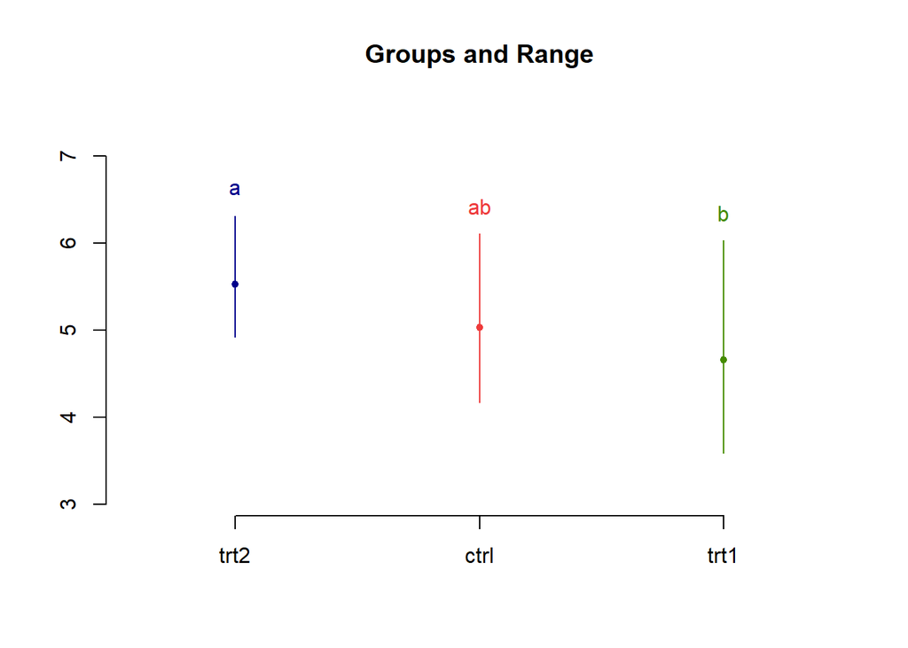

```r
plot(LSD.test(model_rosliny,"group",p.adj = "bonferroni"))
```

*Interpretacja:*

Te które mają wspólną literkę nie wykazują istotnej różnicy

Natomiast tam gdzie jej brak to ta różnica występuje

W naszym przypadku miedzy `trt2` oraz `trt1` występuje ta różnica

# Kontrasty Helmert contr.helmert

liczba kontrastów jest o 1 mniejsza od ilosci grup

rozważamy model

Weight = B_0 + B_1 * g_1 + B_2 * g_2

gdzie zastosowano kontrasty zmiennej group

```r
contrasts(PlantGrowth$group) <- contr.helmert
contrasts(PlantGrowth$group)
```

```
     [,1] [,2]
ctrl   -1   -1
trt1    1   -1
trt2    0    2
```

```r
S <- cbind(1, contrasts(PlantGrowth$group))
S
```

```
     [,1] [,2] [,3]
ctrl    1   -1   -1
trt1    1    1   -1
trt2    1    0    2
```

```r
S_2 <- solve(S)
library(MASS)
print("Macierz współczynników kontrastów:")
```

```
[1] "Macierz współczynników kontrastów:"
```

```r
fractions(S_2)
```

```
     ctrl trt1 trt2
[1,]  1/3  1/3  1/3
[2,] -1/2  1/2    0
[3,] -1/6 -1/6  1/3
```

```r
lm_helmert <- lm(weight ~ group, data = PlantGrowth, contrasts = list(group = contr.helmert))
summary(lm_helmert)
```

```
Call:
lm(formula = weight ~ group, data = PlantGrowth, contrasts = list(group = contr.helmert))

Residuals:
    Min      1Q  Median      3Q     Max
-1.0710 -0.4180 -0.0060  0.2627  1.3690

Coefficients:
            Estimate Std. Error t value Pr(>|t|)
(Intercept)  5.07300    0.11381  44.573  < 2e-16 ***
group1      -0.18550    0.13939  -1.331  0.19439
group2       0.22650    0.08048   2.814  0.00901 **
---
Signif. codes:  0 '***' 0.001 '**' 0.01 '*' 0.05 '.' 0.1 ' ' 1

Residual standard error: 0.6234 on 27 degrees of freedom
Multiple R-squared:  0.2641,    Adjusted R-squared:  0.2096
F-statistic: 4.846 on 2 and 27 DF,  p-value: 0.01591
```

# Kontrasty contr.sum

```r
contrasts(PlantGrowth$group) <- contr.sum
contrasts(PlantGrowth$group)
```

```
     [,1] [,2]
ctrl    1    0
trt1    0    1
trt2   -1   -1
```

```r
S <- cbind(1, contrasts(PlantGrowth$group))
S
```

```
     [,1] [,2] [,3]
ctrl    1    1    0
trt1    1    0    1
trt2    1   -1   -1
```

```r
S_2 <- solve(S)
library(MASS)
print("Macierz współczynników kontrastów:")
```

```
[1] "Macierz współczynników kontrastów:"
```

```r
fractions(S_2)
```

```
     ctrl trt1 trt2
[1,]  1/3  1/3  1/3
[2,]  2/3 -1/3 -1/3
[3,] -1/3  2/3 -1/3
```

```r
lm_sum <- lm(weight ~ group, data = PlantGrowth, contrasts = list(group = contr.sum))
summary(lm_sum)
```

```
Call:
lm(formula = weight ~ group, data = PlantGrowth, contrasts = list(group = contr.sum))

Residuals:
    Min      1Q  Median      3Q     Max
-1.0710 -0.4180 -0.0060  0.2627  1.3690

Coefficients:
            Estimate Std. Error t value Pr(>|t|)
(Intercept)   5.0730     0.1138  44.573   <2e-16 ***
group1       -0.0410     0.1610  -0.255   0.8009
group2       -0.4120     0.1610  -2.560   0.0164 *
---
Signif. codes:  0 '***' 0.001 '**' 0.01 '*' 0.05 '.' 0.1 ' ' 1

Residual standard error: 0.6234 on 27 degrees of freedom
Multiple R-squared:  0.2641,    Adjusted R-squared:  0.2096
F-statistic: 4.846 on 2 and 27 DF,  p-value: 0.01591
```

# Końcowe porady

- *ZAWSZE WSZYTKO DOKLADNIE OPISYWAC*
- *Stawiać H0 i H1*
- *Uzasadniać dokonanie danego testu*
- *Dodać trochę teorii*